# Actuary and Data-Science Study Case

### 1. Exploratory data analysis

### 2. Feature engineering

### 3. Model selection

### 5. Ensemble model

### 6. Prediction

### 7. Conclusion

```python
# !pip install lightgbm>=2.3.1 matplotlib>=3.1.2 numpy>=1.17.4 pandas>=0.25.3 plotly>=4.3.0 seaborn>=0.9.0 scikit-learn>=0.22 xgboost>=0.90
```

```python
import warnings
warnings.filterwarnings('ignore')

import numpy as np
import pandas as pd

import sklearn
from sklearn.preprocessing import StandardScaler
from sklearn.model_selection import train_test_split, cross_val_score, KFold
from sklearn.linear_model import LinearRegression
from sklearn.ensemble import RandomForestRegressor
from sklearn import ensemble
from sklearn.datasets import make_regression
from sklearn.ensemble import AdaBoostRegressor
from xgboost import XGBRegressor
from lightgbm import LGBMRegressor
from sklearn.metrics import make_scorer
from sklearn.metrics import mean_squared_error
from sklearn.experimental import enable_iterative_imputer
from sklearn.impute import IterativeImputer

import matplotlib.pyplot as plt
import seaborn as sns

# Custom created plotting function
from plotting_function import plot_variables
```

# Exploratory Data Analysis

We start by importing and taking a look our dataset.

```python
data = pd.read_csv("Labeled_Data (1).csv", delimiter=';',index_col="index")
data
```

| index | Age | Prime mensuelle | Profession | L'annee de la construction du logement | Departement | Type de vehicule | Score CRM | Niveau de vie | Marque | Salaire annuel | Score credit | Cout entretien annuel | Benefice net annuel |
| --- | --- | --- | --- | --- | --- | --- | --- | --- | --- | --- | --- | --- | --- |
| 0 | 58.0 | 40.0 | Etudiant | 1673 | 106 | SUV | 164 | 3762 | Peugeot | 20420 | 309 | 801 | 54.998558 |
| 1 | 26.0 | 27.0 | Ouvrier | 1737 | 95 | 5 portes | 126 | 3445 | Renault | 25750 | 135 | 667 | 7.840930 |
| 2 | 27.0 | 26.0 | Cadre | 1678 | 136 | SUV | 153 | 986 | Renault | 6790 | 786 | 696 | 46.078889 |
| 3 | 22.0 | 8.0 | Etudiant | 1771 | 96 | 3 portes | 111 | 2366 | Peugeot | 15140 | 320 | 765 | -11.048213 |
| 4 | 60.0 | 20.0 | Sans emploi | 1758 | 101 | 3 portes | 149 | 1441 | Peugeot | 12850 | 287 | 808 | 1.180078 |
| ... | ... | ... | ... | ... | ... | ... | ... | ... | ... | ... | ... | ... | ... |
| 995 | 157.0 | 20.0 | Cadre | 1891 | 111 | 3 portes | 136 | 5443 | Opel | 37970 | 822 | 906 | -11.299972 |
| 996 | 27.0 | 28.0 | Etudiant | 1715 | 111 | 3 portes | 131 | 5425 | Citroen | 36030 | 77 | 1031 | -8.514123 |
| 997 | 41.0 | 2.0 | Etudiant | 1695 | 99 | 5 portes | 142 | 7984 | Citroen | 57600 | 255 | 792 | 11.010143 |
| 998 | 26.0 | 6.0 | Cadre | 1972 | 104 | SUV | 129 | 3365 | Citroen | 25760 | 756 | 763 | 20.430019 |
| 999 | 31.0 | 37.0 | Cadre | 1835 | 101 | 3 portes | 132 | 2454 | Opel | 19550 | 606 | 776 | -6.200464 |

1000 rows × 13 columns

```python
sample=data
total = sample.isnull().sum().sort_values(ascending=False)
percent = (sample.isnull().sum()/sample.isnull().count()).sort_values(ascending=False)
missing_data = pd.concat([total, percent], axis=1, keys=['Total', 'Percent'])
missing_data
```

|  | Total | Percent |
| --- | --- | --- |
| Marque | 52 | 0.052 |
| Age | 17 | 0.017 |
| Prime mensuelle | 11 | 0.011 |
| Benefice net annuel | 0 | 0.000 |
| Cout entretien annuel | 0 | 0.000 |
| Score credit | 0 | 0.000 |
| Salaire annuel | 0 | 0.000 |
| Niveau de vie | 0 | 0.000 |
| Score CRM | 0 | 0.000 |
| Type de vehicule | 0 | 0.000 |
| Departement | 0 | 0.000 |
| L'annee de la construction du logement | 0 | 0.000 |
| Profession | 0 | 0.000 |

3 of the variables have missing values. We can either fill them with the mean/median/mode or drop them.

For now we will just fill them with some placeholder values so we can visualize our data and deal with them at a later stage.

```python
sample["Age"].fillna(200,inplace=True)
sample["Marque"].fillna("Not av",inplace=True)
```

We start by looking at the distribution of the categorical and discrete variables in our dataset.

```python
cat_disc_vars = [var for var in list(data) if var not in ('Age','Prime mensuelle',
       "L'annee de la construction du logement", 'Departement',
       'Score CRM', 'Niveau de vie',
       'Salaire annuel', 'Score credit', 'Cout entretien annuel',
       'Benefice net annuel')]
plot_variables(cat_disc_vars, 0, data)
```

[interactive chart not shown]

We now look at the distribution of the continuous variables.

```python
#We created a copy of the dataset inorder to fill the nan values to visualise it
data1=sample.copy()
data1['Prime mensuelle'].fillna(90,inplace =True)
plot_variables(['Age','Prime mensuelle','Departement' ,
       "L'annee de la construction du logement", 'Score CRM', 'Niveau de vie',
       'Salaire annuel', 'Score credit', 'Cout entretien annuel',
       'Benefice net annuel'], 1, data1)
```

[interactive chart not shown]

# Feature engineering

When looking to the age variable we saw that some variables exceed 120 and others that are null. This might mean that those are old conrtracts or just that those are wrong values we will replace all of them with the median

```python
a=sample["Age"].median()
sample["Age"].loc[(sample["Age"] > 120)] = 200
sample["Age"].loc[(sample["Age"] < 18)] = 200
sample['No Age'] = sample['Age'].apply(lambda x: 1 if x == 200 else 0)
sample["Age"].replace(200,a,inplace=True)
```

We will divide the age distribution into 3 categories. First one is 18->30 second is 31 -> 55 and third one is 56->100 and we will one hot encode it.

```python
sample["Age"].astype('str').dtypes
sample["Age"].loc[(sample['Age'] < 31)] = 1
sample["Age"].loc[(sample['Age'] > 55)] = 3
sample["Age"].loc[(sample['Age'] > 30)] = 2
Age= pd.get_dummies(sample["Age"], drop_first=True)
sample=pd.concat([sample, Age], axis=1, join='inner')
sample.drop("Age",axis=1,inplace=True)
```

We will do the same thing with the "Marque" variable replacing it this time with the mode.

```python
#Filling the missing variables
sample["No Marque"] = sample["Marque"].apply(lambda x: 1 if x == "Not av" else 0)
sample["Marque"].replace("Not av",sample["Marque"].mode()[0],inplace=True)
#One Hot encoding
Mar= pd.get_dummies(sample["Marque"], drop_first=True)
sample=pd.concat([sample, Mar], axis=1, join='inner')
sample.drop("Marque",axis=1,inplace=True)
```

Although the *departement* variable might have include some information about the way traffic behaves in that area. In this case using it just the way it is will create a biais or an overfitting problem. An alternative solution to use such informtion in the model is to include the number of claims in the departement. So we will choose to drop this feature. Same goes for the *L'annee de la construction du logement* which seems to not have a big effect on the data.

```python
sample.drop("Departement",axis=1,inplace=True)
sample.drop("L'annee de la construction du logement",axis=1,inplace=True)
```

For the *Profession* variable we will use ordinal encoding since we know that "cadre" > "ouvrier" > "etudiant": A student is riskier than worker etc..

```python
ordinal_categories = {"Profession": {'Cadre':5, 'Etudiant':2, 'Ouvrier':4, 'Sans emploi':1, 'Travailleur non salarie':3}}

for category in ordinal_categories:
    sample[category] = sample[category].map(ordinal_categories[category]).astype("int64")
```

For the rest of the categorical data we will use one hot encoding

```python
sample= pd.get_dummies(sample, drop_first=True)
```

In order to fill the missing "Prime" values. We use the values of other variables.

```python
imp = IterativeImputer(max_iter=10, random_state=0)
a=imp.fit(sample)
```

```python
sample1= pd.DataFrame(imp.transform(sample))
sample["Prime mensuelle"]=sample1[0]
```

```python
#See how many null values we have got
total = sample.isnull().sum().sort_values(ascending=False)
percent = (sample.isnull().sum()/sample.isnull().count()).sort_values(ascending=False)
missing_data = pd.concat([total, percent], axis=1, keys=['Total', 'Percent'])
missing_data
```

|  | Total | Percent |
| --- | --- | --- |
| Type de vehicule_Utilitaire | 0 | 0.0 |
| Type de vehicule_SUV | 0 | 0.0 |
| Profession | 0 | 0.0 |
| Score CRM | 0 | 0.0 |
| Niveau de vie | 0 | 0.0 |
| Salaire annuel | 0 | 0.0 |
| Score credit | 0 | 0.0 |
| Cout entretien annuel | 0 | 0.0 |
| Benefice net annuel | 0 | 0.0 |
| No Age | 0 | 0.0 |
| 2.0 | 0 | 0.0 |
| 3.0 | 0 | 0.0 |
| No Marque | 0 | 0.0 |
| Opel | 0 | 0.0 |
| Peugeot | 0 | 0.0 |
| Renault | 0 | 0.0 |
| Toyota | 0 | 0.0 |
| Volkswagen | 0 | 0.0 |
| Type de vehicule_5 portes | 0 | 0.0 |
| Prime mensuelle | 0 | 0.0 |

```python
#Because variables have diffrent ranges, often ordres of magnitudes of others, we will normalize/scale them
# Only numeric values

scale=StandardScaler()
sample['Niveau de vie'] = scale.fit_transform(sample['Niveau de vie'].values.reshape(-1, 1))
sample['Prime mensuelle'] = scale.fit_transform(sample['Prime mensuelle'].values.reshape(-1, 1))
sample['Cout entretien annuel'] = scale.fit_transform(sample['Cout entretien annuel'].values.reshape(-1, 1))
sample['Score credit'] = scale.fit_transform(sample['Score credit'].values.reshape(-1, 1))
sample['Score CRM'] = scale.fit_transform(sample['Score CRM'].values.reshape(-1, 1))
sample['Salaire annuel'] = scale.fit_transform(sample['Salaire annuel'].values.reshape(-1, 1))
#sample['Benefice net annuel'] = scale.fit_transform(sample['Benefice net annuel'].values.reshape(-1, 1))
```

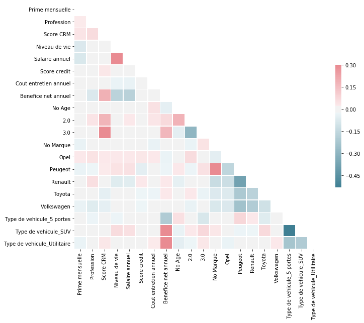

```python
corr = sample.corr()
mask = np.zeros_like(corr, dtype=np.bool)
mask[np.triu_indices_from(mask)] = True
f, ax = plt.subplots(figsize=(11, 9))
cmap = sns.diverging_palette(220, 10, as_cmap=True)
sns.heatmap(corr, mask=mask, cmap=cmap, vmax=.3, center=0,
            square=True, linewidths=.5, cbar_kws={"shrink": .5})
```

We can see that the correlation coefficients are not particularly high, indicating the lack of multicollinearity. This eliminates the need for exploring certain dimension reduction techniques such as PCA.

```python
X = sample.drop('Benefice net annuel', axis=1)
y = sample['Benefice net annuel']
```

# Model selection

In this section we test various baseline models. We will use 5-fold crossvalidation to determine the best candidate models moving forward. "Best" is defined as having the lowest RMSE

```python
def rmse(actual, predicted):
    return np.sqrt(mean_squared_error(actual, predicted))

rmse_score = make_scorer(rmse)
```

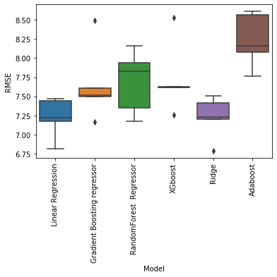

```python
models = {'Linear Regression' : LinearRegression(),
          'Gradient Boosting regressor': ensemble.GradientBoostingRegressor(),
          'RandomForest  Regressor': ensemble.RandomForestRegressor(),
          'XGboost': XGBRegressor(objective="reg:squarederror"),
        #  'Lasso':sklearn.linear_model.Lasso(),
        'Ridge' : sklearn.linear_model.Ridge(),
        'Adaboost': AdaBoostRegressor()}

results = pd.DataFrame(columns=models)
for model in models:
    kfold = KFold(shuffle=True, n_splits=5, random_state=0)
    cvResults = cross_val_score(models[model], X, y, cv=kfold, scoring=rmse_score)
    results[model] = cvResults

bxplot = sns.boxplot(x="Model", y="RMSE", data=results.melt(var_name="Model", value_name="RMSE"))
_ = bxplot.set_xticklabels(bxplot.get_xticklabels(), rotation=90)
```

So as we can see the best models are Linear Regression, Ridge and Gradient boosting Regressor are the best models

# Ensemble model

We will now explore whether an ensemble model that aggregates the previous best 3 models performs better.For that we will seperate our dataset into training (for fitting the models) and testing (to test the ensemble model).

```python
X_train, X_test, y_train, y_test = train_test_split(X, y,
                                                        test_size=0.2,
                                                        shuffle=True,
                                                        random_state=0)
```

```python
model1 = LinearRegression()
model1.fit(X_train, y_train)
preds_linear = model1.predict(X_test)
print('Linear regression RMSE: ', rmse(y_test,preds_linear))

model2 = sklearn.linear_model.Ridge()
model2.fit(X_train, y_train)
preds_ridge = model2.predict(X_test)
print('Ridge regression RMSE: ', rmse(y_test,preds_ridge))

model3 = ensemble.GradientBoostingRegressor()
model3.fit(X_train, y_train)
preds_gboost = model3.predict(X_test)
print('Gradient Boosting RMSE: ', rmse(y_test,preds_gboost))

preds = (1*preds_linear+2*preds_ridge+preds_gboost)/4

print('Weighed Average Ensemble model RMSE: ', rmse(y_test,preds))
```

```
Linear regression RMSE:  6.813723972273864
Ridge regression RMSE:  6.786811711850588
Gradient Boosting RMSE:  7.194722340695514
Weighed Average Ensemble model RMSE:  6.784139030643207
```

We can see that the weighed ensemble model has a lower RMSE than each of the individuals models. We will thus train our 3 models on the entire dataset and use the ensemble to produce the prodecitions.

The RMSE might seem high but it is relative to the non-scaled net income.

# Prediction

We start by taking a look at the prediction dataset.

```python
Scoring_data = pd.read_csv("Scoring_Data (1).csv", delimiter=';',index_col="index")
```

```python
#See how many null values we have got
total1 = Scoring_data.isnull().sum().sort_values(ascending=False)
percent1 = (Scoring_data.isnull().sum()/Scoring_data.isnull().count()).sort_values(ascending=False)
missing_data = pd.concat([total1, percent1], axis=1, keys=['Total', 'Percent'])
missing_data
```

|  | Total | Percent |
| --- | --- | --- |
| Marque | 17 | 0.056667 |
| Age | 5 | 0.016667 |
| Prime mensuelle | 2 | 0.006667 |
| Cout entretien annuel | 0 | 0.000000 |
| Score credit | 0 | 0.000000 |
| Salaire annuel | 0 | 0.000000 |
| Niveau de vie | 0 | 0.000000 |
| Score CRM | 0 | 0.000000 |
| Type de vehicule | 0 | 0.000000 |
| Coefficient bonus malus | 0 | 0.000000 |
| Kilometres parcourus par mois | 0 | 0.000000 |
| Categorie socio professionnelle | 0 | 0.000000 |

```python
cat_disc_vars1 = [var for var in list(Scoring_data) if var not in ('Age','Prime mensuelle',
       'Score CRM', 'Niveau de vie', 'Coefficient bonus malus','Kilometres parcourus par mois'
       'Salaire annuel', 'Score credit', 'Cout entretien annuel')]
plot_variables(cat_disc_vars1, 0, Scoring_data)
```

[interactive chart not shown]

```python
#We created a copy of the dataset inorder to fill the nan values to visualise it
data1=Scoring_data.copy()
data1['Prime mensuelle'].fillna(90,inplace =True)
data1['Age'].fillna(200,inplace =True)
plot_variables(['Age','Prime mensuelle',
       "Coefficient bonus malus","Kilometres parcourus par mois" ,'Score CRM', 'Niveau de vie',
       'Salaire annuel', 'Score credit', 'Cout entretien annuel'], 1, data1)
```

[interactive chart not shown]

The prediction data set seems to follow the same distribution as our training data which is good news. We will transform the data accordingly (similarly to the training data)

```python
Scoring_data["Age"].fillna(200,inplace=True)
Scoring_data["Marque"].fillna("Not av",inplace=True)
```

```python
a=Scoring_data["Age"].median()
Scoring_data["Age"].loc[(Scoring_data["Age"] > 120)] = 200
Scoring_data["Age"].loc[(Scoring_data["Age"] < 18)] = 200
Scoring_data['No Age'] = Scoring_data['Age'].apply(lambda x: 1 if x == 200 else 0)
Scoring_data["Age"].replace(200,a,inplace=True)
Scoring_data["Age"].astype('str').dtypes
Scoring_data["Age"].loc[(Scoring_data['Age'] < 31)] = 1
Scoring_data["Age"].loc[(Scoring_data['Age'] > 55)] = 3
Scoring_data["Age"].loc[(Scoring_data['Age'] > 30)] = 2
Age= pd.get_dummies(Scoring_data["Age"], drop_first=True)
Scoring_data=pd.concat([Scoring_data, Age], axis=1, join='inner')
Scoring_data.drop("Age",axis=1,inplace=True)
```

```python
#Filling the missing variables
Scoring_data["No Marque"] = Scoring_data["Marque"].apply(lambda x: 1 if x == "Not av" else 0)
Scoring_data["Marque"].replace("Not av",Scoring_data["Marque"].mode()[0],inplace=True)
#One Hot encoding
Mar= pd.get_dummies(Scoring_data["Marque"], drop_first=True)
Scoring_data=pd.concat([Scoring_data, Mar], axis=1, join='inner')
Scoring_data.drop("Marque",axis=1,inplace=True)
```

```python
Scoring_data.drop("Coefficient bonus malus",axis=1,inplace=True)
Scoring_data.drop("Kilometres parcourus par mois",axis=1,inplace=True)
```

```python
ordinal_categories = {"Categorie socio professionnelle": {'Cadre':5, 'Etudiant':2, 'Ouvrier':4, 'Sans emploi':1, 'Travailleur non salarie':3}}

for category in ordinal_categories:
    Scoring_data[category] = Scoring_data[category].map(ordinal_categories[category]).astype("int64")
```

```python
Scoring_data.rename(columns={"Categorie socio professionnelle": "Profession"})
```

| index | Prime mensuelle | Profession | Type de vehicule | Score CRM | Niveau de vie | Salaire annuel | Score credit | Cout entretien annuel | No Age | 2.0 | 3.0 | No Marque | Opel | Peugeot | Renault | Toyota | Volkswagen |
| --- | --- | --- | --- | --- | --- | --- | --- | --- | --- | --- | --- | --- | --- | --- | --- | --- | --- |
| 1000 | 16.0 | 5 | Utilitaire | 121 | 4956 | 31600 | 401 | 756 | 0 | 0 | 0 | 0 | 0 | 0 | 0 | 1 | 0 |
| 1001 | 14.0 | 5 | 5 portes | 125 | 4531 | 34900 | 833 | 719 | 0 | 0 | 0 | 0 | 1 | 0 | 0 | 0 | 0 |
| 1002 | 13.0 | 5 | 5 portes | 140 | 9541 | 62820 | 890 | 1027 | 0 | 0 | 0 | 1 | 0 | 1 | 0 | 0 | 0 |
| 1003 | 2.0 | 2 | 5 portes | 132 | 6536 | 45450 | 990 | 964 | 0 | 1 | 0 | 0 | 0 | 0 | 0 | 0 | 0 |
| 1004 | 6.0 | 4 | 5 portes | 127 | 10985 | 74270 | 647 | 768 | 0 | 0 | 0 | 0 | 0 | 0 | 0 | 0 | 1 |
| ... | ... | ... | ... | ... | ... | ... | ... | ... | ... | ... | ... | ... | ... | ... | ... | ... | ... |
| 1295 | 22.0 | 1 | 5 portes | 166 | 1874 | 7400 | 83 | 825 | 0 | 0 | 1 | 0 | 1 | 0 | 0 | 0 | 0 |
| 1296 | 22.0 | 2 | 5 portes | 89 | 1207 | 4310 | 228 | 703 | 0 | 0 | 0 | 0 | 0 | 0 | 0 | 1 | 0 |
| 1297 | 14.0 | 5 | SUV | 120 | 977 | 10070 | 902 | 702 | 0 | 0 | 0 | 0 | 0 | 0 | 0 | 0 | 0 |
| 1298 | 8.0 | 2 | Utilitaire | 131 | 3695 | 32360 | 271 | 771 | 0 | 1 | 0 | 0 | 1 | 0 | 0 | 0 | 0 |
| 1299 | 4.0 | 3 | 5 portes | 144 | 7973 | 48570 | 495 | 789 | 1 | 1 | 0 | 0 | 0 | 0 | 0 | 1 | 0 |

300 rows × 17 columns

```python
Scoring_data= pd.get_dummies(Scoring_data, drop_first=True)
```

```python
imp1 = IterativeImputer(max_iter=10, random_state=0)
a1=imp1.fit(Scoring_data)
Scoring_data1= pd.DataFrame(imp1.transform(Scoring_data))
s=1000
for i in Scoring_data1[0]:
    Scoring_data["Prime mensuelle"][s]=i
    s=s+1
```

```python
#Because variables have diffrent ranges, often ordres of magnitudes of others, we will normalize/scale them
# Only numeric values

scale=StandardScaler()
Scoring_data['Niveau de vie'] = scale.fit_transform(Scoring_data['Niveau de vie'].values.reshape(-1, 1))
Scoring_data['Prime mensuelle'] = scale.fit_transform(Scoring_data['Prime mensuelle'].values.reshape(-1, 1))
Scoring_data['Cout entretien annuel'] = scale.fit_transform(Scoring_data['Cout entretien annuel'].values.reshape(-1, 1))
Scoring_data['Score credit'] = scale.fit_transform(Scoring_data['Score credit'].values.reshape(-1, 1))
Scoring_data['Score CRM'] = scale.fit_transform(Scoring_data['Score CRM'].values.reshape(-1, 1))
Scoring_data['Salaire annuel'] = scale.fit_transform(Scoring_data['Salaire annuel'].values.reshape(-1, 1))
```

```python
model1 = LinearRegression()
model1.fit(X, y)
preds_linear = model1.predict(Scoring_data)

model2 = sklearn.linear_model.Ridge()
model2.fit(X, y)
preds_ridge = model2.predict(Scoring_data)

model3 = ensemble.GradientBoostingRegressor()
model3.fit(X, y)
preds_gboost = model3.predict(Scoring_data)

preds = (1*preds_linear+2*preds_ridge+preds_gboost)/4

print(preds)
```

```
[ 44.72394248   6.07415041   1.28273082  12.0125522   -1.86146425
   9.15837269   2.52660232 -12.87472982  41.20011165  31.99416568
  13.56797885  29.72496346  25.74254862  10.19253879  56.57793686
  -2.87342842  13.09760766   8.65395377  31.28587756  16.82152579
  38.19369074  -5.42170307  29.68938212  53.93329874  31.47419565
  -5.10500983  46.24486348  12.61506754  -5.07147243   0.797088
  59.28764879  16.00223911  24.00429966  -2.78133361  36.78481865
  -9.28156018  12.48994261  -4.61511763  33.74414032  27.84274242
  29.95519837  11.47565028  31.94560368  -1.69398504  10.58534241
  -4.44581057  16.44988739  34.77010967  -2.55381563   9.15338151
  11.62468153  26.7144657   14.11240075  40.68196829  -4.92117677
   9.28880661  28.85312846  53.41507404  12.89595554 -12.82689499
  21.36692197  25.71259881  29.24726484 -11.24327104  13.99385074
  17.87221657  53.50129162  17.32803259  13.52408925  15.01717192
  47.84747506  -8.02286565  -9.92445612   2.24672304 -16.70490877
  33.05289123 -16.54260026  38.73198713  40.38161258  13.42585656
  37.97280387  33.05223986  15.32598942  29.89497674  48.52148513
  30.02133365  14.04887687   7.18947784  -9.0611141   13.62903119
  16.06858308  15.53560532  18.05353706  -4.8749934   -1.08940076
  28.99087682  14.70240934  33.40194684  15.70352663  19.99946511
  -0.16827431  -5.7917681   -8.3239988   31.24287169  30.45446638
  45.65761757  13.85228975  11.32394888  14.79613362  30.46738622
  27.90177888   5.95746616  -9.87923602  47.22039     30.93678626
  28.01445236  34.05206234   5.4956365   -8.58964675  16.83367285
  -8.85598343  10.60025017  15.29578546  -6.90739674  10.91846491
  21.38081384  -4.26248113  13.55302842  19.25047629  33.58742957
  20.65659546  11.01840766  36.20801726  28.34391672   0.27916697
  -9.89105905  19.94524242  -6.89391916  32.34808489  34.91535948
  30.90577724  12.7339368    5.25557138   7.74365479   3.61805443
  -9.54444497   5.26475072   9.40062482  -3.00351267   4.34666105
   0.12633943  14.54444217  14.19427944  29.4445589   19.27412039
  36.47577781  18.10310109   0.81358444  43.03153494   8.22988206
   6.43049411  34.16049414 -10.05645056  -9.50431581  27.43933144
 -10.03668071   6.24209972  32.54995471  30.5989152   11.12746572
  18.97292648  45.51589584  29.63359798   6.8547032   12.56447083
  -4.8120716   -5.7108541    9.14344214  35.04405333  16.39346113
  10.77737777   9.47905151  14.92141194  -9.28011844  58.5245051
   2.59209779  50.13368143   4.42005957   7.35707311  -1.80527542
  -4.67331408  15.37948653  10.49948279  -2.73146324  33.14428998
 -15.81686919  39.15198615  54.00537522  42.86340436  48.65143265
  13.30257255  15.07894262  28.46314782   2.46443403  25.87290428
  10.82475118  15.81037978 -12.42356972  32.56399176  14.14660551
  27.76406903  -1.24044837  11.58673242  -1.06150255  22.13700167
  -4.57533192  15.16812391  16.97056459  10.21739003  -6.84582608
  12.53083593  32.87168858   5.88415914  28.99238615  -7.53144762
  28.26936253  37.51940632   8.06195454   6.95355257  13.11262419
   8.4499881   10.16878492  36.36699139   8.95990174  34.80001004
  -2.26970385  29.73768462  16.50552131  32.38386179  15.39909209
   1.28384542   8.29988423  36.84614195  49.34496985  29.63416248
  58.4262949   13.87492503   6.53997617  20.67863752  11.97704252
 -16.03907687   1.82546337  11.41430383  -8.20890672  54.5989251
  -0.88776146  38.67648129  59.80950512  32.43974737  12.98839008
  14.72387648  16.00960798  17.8165621   15.88470166  41.02521299
  13.05944122  11.09728294  -7.50475206  20.31684438  -4.96362898
  -5.47005924  10.77425725 -11.03467462  14.98520024  20.253229
   0.88835643  34.08084722  11.12563271  -9.8925903    1.12146867
  14.77388224   9.60267336  38.7344678   -9.82962889  35.70448702
  44.75697963  -5.87462927  29.75254663  31.37934499  31.82150135
   6.69966317  -8.4990565   12.95580064  38.68453529  49.4929759
  27.47318082  14.0378472   31.17583469  50.65058762  10.09249929]
```

```python
df = pd.DataFrame(data=preds)
df1=df.rename(columns={0: "Predictions"})
df1.to_csv('Prediction3.csv',index=True)
```

# Conclusion

We have only tried a small number of models but the possibities are endless, neural networks are an option but we decided against it given the small size of our dataset. We can also improve the performance of the models by tuning their hyperparameters on a validation set. Feature Selection can also help produce parsimonious models.